# The Evolution of the Movie

### *Do they make 'em like they used to?*

It's often said that films are getting longer, and possibly even more commonly said that they have gotten worse over the years. After all, [the golden age of Hollywood](https://www.arcadiapublishing.com/Navigation/Community/Arcadia-and-THP-Blog/June-2019/The-Rise-and-Fall-of-Hollywood%E2%80%99s-Golden-Age) ended about sixty years ago.

Using data science techniques, we will explore how much of that is fact and how much is fiction...

#### by William Gerst - CMSC320 - 17 May 2021

# Introduction

Let's look at the total film runtimes of some of the most popular movies throughout time, according to the American Film Institute's [100 Years... 100 Movies](https://www.afi.com/afis-100-years-100-movies/) collection of classic films.

[figure not shown]

Back in 1927, we see [*The Jazz Singer*](https://www.imdb.com/title/tt0018037/) runs for about 88 minutes in total.

The 1939 Frank Capra classic [*Mr. Smith Goes to Washington*](https://www.imdb.com/title/tt0031679/) clocks in at 129 minutes.

Then, in 1976, Robert Redford's hit [*All the President's Men*](https://www.imdb.com/title/tt0074119/) hits 138 minutes in total.

The most recent entry on the list is 2001's fantasy film [*The Lord of the Rings: The Fellowship of the Ring*](https://www.imdb.com/title/tt0120737/) which reaches an astounding 178 minute runtime.

Inspecting only this short list of movies suggests that perhaps there is some kernel of truth to the claim that movies have been getting longer. However, it's not too hard to find counterexamples to this trend, even on that same list from the AFI. For instance, [*Gone with the Wind*](https://www.imdb.com/title/tt0031381/) from 1939 achieves a runtime of 238 minutes, higher than any of the four others listed above.

Clearly, no number of anecdotal examples will be sufficient to finally prove or disprove this idea that movies runtimes have been increasing. To do that, we will instead perform large-scale data analysis on the set of all movies with pages on the [Internet Movie Database](https://www.imdb.com/), or IMDb.

Before moving on, one more observation to make is that the user ratings for the four films above tended to increase with time. In sequence, they received IMDb scores of 6.5, 8.1, 8.0, and 8.8 out of 10, respectively. In the analysis that follows, we will investigate to see if this pattern holds up in general, not just for those special few on the aforementioned AFI list.

# Gathering the Data

IMDb provides a multitude of different datasets described [on their website](https://www.imdb.com/interfaces/). These datasets contain information ranging from basic facts like the titles of movies and TV shows to the specific job titles of principal cast and crew members for particular works.

For our purposes, all we need are the files `title.basics.tsv.gz`, which contains the titles, dates, and runtimes of films, and `title.ratings.tsv.gz`, which (as expected) holds the average user ratings for each work.

These files can be directly downloaded from https://datasets.imdbws.com/ and extracted to make the files `basics.tsv` and `ratings.tsv`, respectively. These files, which together comprise about 700 MB, can be placed in the directory `imdbData/`.

After this, we can use [Pandas](https://pandas.pydata.org/) to read in the files directly into DataFrames for easy processing. Pandas is a user-friendly data management package for Python which allows quick and easy data storage and manipulation in a 2D table format, similar in concept to SQL databases.

```python
import pandas as pd

imdbPath = "imdbData/"

# Set the columns we want in the tables
basicsCols = ["tconst", "titleType", "primaryTitle", "startYear", "runtimeMinutes"]
ratingsCols = ["tconst", "averageRating"]

# Read in the TSV files
basics = pd.read_csv(imdbPath + "basics.tsv", sep='\t', usecols=basicsCols, low_memory=False)
# low_memory=False is used because otherwise the large file size causes error messages
ratings = pd.read_csv(imdbPath + "ratings.tsv", sep='\t', usecols=ratingsCols)

basics.head()
```

|  | tconst | titleType | primaryTitle | startYear | runtimeMinutes |
| --- | --- | --- | --- | --- | --- |
| 0 | tt0000001 | short | Carmencita | 1894 | 1 |
| 1 | tt0000002 | short | Le clown et ses chiens | 1892 | 5 |
| 2 | tt0000003 | short | Pauvre Pierrot | 1892 | 4 |
| 3 | tt0000004 | short | Un bon bock | 1892 | 12 |
| 4 | tt0000005 | short | Blacksmith Scene | 1893 | 1 |

By specifying the columns we want, we strip away all the unwanted information contained in each file. For instance, the `basics.tsv` file has columns for the original title (in case it was modified), whether it is an adult film, TV series end year, and a list of applicable genres. The `ratings.tsv` file, on the other hand, has a column for tracking the number of votes on a particular title, which is not relevant to our needs.

This data still needs to be cleaned up some more. For one, the `basics` table currently contains a lot more than just movies. The `titleType` column has options for movies, shorts, TV series, TV episodes, videos, and more. We want to filter out every non-movie item and drop those from the DataFrame.

Next, we want to combine the two tables together so that we can associate a particular title with its rating. This can be managed via the Pandas Dataframe `.join()` function, which operates in a similar way to the JOIN class of functions in SQL.

```python
basics = basics[basics["titleType"] == "movie"]

basics.head()
```

|  | tconst | titleType | primaryTitle | startYear | runtimeMinutes |
| --- | --- | --- | --- | --- | --- |
| 498 | tt0000502 | movie | Bohemios | 1905 | 100 |
| 570 | tt0000574 | movie | The Story of the Kelly Gang | 1906 | 70 |
| 587 | tt0000591 | movie | The Prodigal Son | 1907 | 90 |
| 610 | tt0000615 | movie | Robbery Under Arms | 1907 | \N |
| 625 | tt0000630 | movie | Hamlet | 1908 | \N |

It appears from the output above that the very first movie listed on the IMDb website is [*Bohemios*](https://www.imdb.com/title/tt0000502/), a silent film from 1905. (Looking at the above, we also see that some rows have `\N` in the `runtimeMinutes` column, which simply indicates that a runtime for the title is not available.)

```python
movieData = basics.join(ratings.set_index("tconst"), on="tconst", how="left")

movieData.head(400000)
```

|  | tconst | titleType | primaryTitle | startYear | runtimeMinutes | averageRating |
| --- | --- | --- | --- | --- | --- | --- |
| 498 | tt0000502 | movie | Bohemios | 1905 | 100 | 4.5 |
| 570 | tt0000574 | movie | The Story of the Kelly Gang | 1906 | 70 | 6.1 |
| 587 | tt0000591 | movie | The Prodigal Son | 1907 | 90 | 6.0 |
| 610 | tt0000615 | movie | Robbery Under Arms | 1907 | \N | 4.5 |
| 625 | tt0000630 | movie | Hamlet | 1908 | \N | 3.8 |
| ... | ... | ... | ... | ... | ... | ... |
| 4672375 | tt2815038 | movie | Le veilleur | 2010 | 50 | NaN |
| 4672383 | tt2815060 | movie | Come Hell or High Water | 2009 | 89 | NaN |
| 4672389 | tt2815072 | movie | Indigenous | 2014 | 86 | 4.7 |
| 4672403 | tt2815102 | movie | Praï chang | 2010 | 50 | NaN |
| 4672418 | tt2815138 | movie | Alien Valley | 2012 | 78 | 4.3 |

400000 rows × 6 columns

The merge was performed via a `LEFT JOIN` because this ensures that every single movie is still preserved as a row in the DataFrame, even if it is unrated by the users on the IMDb website. We can see from the output above that films like *Come Hell or High Water* (2009) meet this description.

# Exploration and Initial Analysis

```python
len(movieData)
```

```
576920
```

Now that we have our release year, runtime, and rating data collected in one place, we want to aggregate the results. There is no practical way to display the information for more than 570,000 different films throughout time, so we will instead take the averages for each year that is present in the table.

```python
import numpy as np

# Returns the average of a series of numbers
def avg(ls):
    return sum(ls) / len(ls)

averageMovieData = pd.DataFrame(columns=["year", "frequency", "averageRating", "averageRuntime"])

# Make a list of all years that appear in the IMDb data
years = set(y for y in movieData["startYear"] if y != "\\N" and int(y) < 2022)

# Keep a list of dictionaries for aggregate movie data by year
yearDatas = []

# Make an entry for every year that appears in the data
for yr in sorted(years):
    moviesByYear = movieData[movieData["startYear"] == yr]
    freq = len(moviesByYear)

    # We take the average of all movies with user ratings, if any
    yearRatings = moviesByYear["averageRating"].dropna()
    if not yearRatings.empty:
        averageRating = avg(yearRatings)
    else:
        averageRating = np.nan

    # Now, we take the average of all movies with listed runtimes, if any
    runtimes = [int(r) for r in moviesByYear["runtimeMinutes"] if r != "\\N"]
    if runtimes:
        averageRuntime = avg(runtimes)
    else:
        averageRuntime = np.nan

    yearData = {
        "year": int(yr),
        "frequency": freq,
        "averageRating": averageRating,
        "averageRuntime": averageRuntime
    }

    yearDatas.append(yearData)

# Create a DataFrame for storing aggregate movie data by year
averageMovieData = pd.DataFrame(yearDatas, columns=["year", "frequency", "averageRating", "averageRuntime"])

averageMovieData.head(150)
```

|  | year | frequency | averageRating | averageRuntime |
| --- | --- | --- | --- | --- |
| 0 | 1896 | 1 | 6.400000 | 61.000000 |
| 1 | 1897 | 1 | 4.500000 | NaN |
| 2 | 1898 | 7 | NaN | NaN |
| 3 | 1899 | 8 | 3.800000 | 135.000000 |
| 4 | 1900 | 6 | 6.150000 | 59.500000 |
| ... | ... | ... | ... | ... |
| 121 | 2017 | 17903 | 6.245111 | 90.221566 |
| 122 | 2018 | 17716 | 6.149388 | 91.149975 |
| 123 | 2019 | 17041 | 6.165728 | 94.762865 |
| 124 | 2020 | 14508 | 6.222450 | 89.640135 |
| 125 | 2021 | 9813 | 6.366378 | 93.944295 |

126 rows × 4 columns

We see that the average movie statistics are starting to take shape. Interestingly, we can see the frequency of movies in recent years is many orders of magnitude higher than those in the earliest years of film. Additionally, we can even see the decrease in movie frequency in the year 2020, presumably due to the industry slowdown caused by the worldwide COVID-19 pandemic.

Note that at this point, we have stripped all title data from the movies, storing only information for the years collectively. This means there is one row for each of the 126 years from 1896 to 2021, as seen above. (The rows of the table have been sorted by year, due to the way it was constructed.) Also note that any movies that lacked year data were removed in the processing above, since then their rating and runtime become useless information in this context. Finally, a value of `NaN` in this aggregate data table means that every single movie in that year lacked the appropriate information on IMDb, as is the case for the seven movies in 1898 that have no ratings or listed runtimes.

Let's plot the overall frequency of movies over time and see if there are any other preliminary trends that appear. This will be done via the [`matplotlib`](https://matplotlib.org/) package for Python, which allows for very easy plotting of data and is compatible with Pandas Series data.

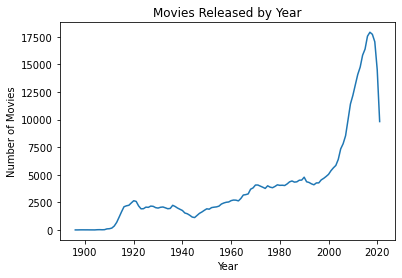

```python
import matplotlib.pyplot as plt

plt.plot(averageMovieData["year"], averageMovieData["frequency"])
plt.title("Movies Released by Year")
plt.xlabel("Year")
plt.ylabel("Number of Movies")
plt.show()
```

As we might have expected, the number of movies per year remains stagnant until about 1910, whereupon the count begins to increase dramatically over time, eventually peaking at just below 18,000 movies in 2017. Then, in 2020, there is a significant drop in the movie count, followed by a decrease to less than 10,000 in 2021. (This last change, however, is less severe than it may at first appear. As of the time of writing, there are more than six months left in the 2021 calendar year, so there is plenty of opportunity left for this number to meet or exceed previous years' values.)

The change in movie quantity from 2000 to 2020, however, is far greater in scale than anything seen previously. Indeed, we can even see a slight decrease in movie quantity during ranges like 1940 to 1945, during which the resources of the United States were presumably diverted to fighting World War II.

We can follow up by plotting the average ratings and runtimes by year, as well.

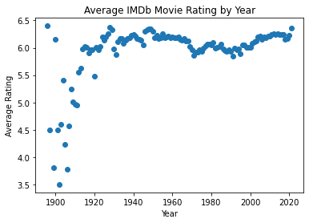

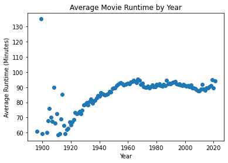

```python
plt.scatter(averageMovieData["year"], averageMovieData["averageRating"])
plt.title("Average IMDb Movie Rating by Year")
plt.xlabel("Year")
plt.ylabel("Average Rating")
plt.show()

plt.scatter(averageMovieData["year"], averageMovieData["averageRuntime"])
plt.title("Average Movie Runtime by Year")
plt.xlabel("Year")
plt.ylabel("Average Runtime (Minutes)")
plt.show()
```

These graphs are terribly noisy - we see there are massive swings in both runtime and rating in the early years, prior to 1920. This, we predict, is likely due to the extremely low frequency of movies listed from that time period. Let us see the frequencies for each of these years:

```python
averageMovieData.head(20)
```

|  | year | frequency | averageRating | averageRuntime |
| --- | --- | --- | --- | --- |
| 0 | 1896 | 1 | 6.400000 | 61.000000 |
| 1 | 1897 | 1 | 4.500000 | NaN |
| 2 | 1898 | 7 | NaN | NaN |
| 3 | 1899 | 8 | 3.800000 | 135.000000 |
| 4 | 1900 | 6 | 6.150000 | 59.500000 |
| 5 | 1901 | 7 | 4.500000 | NaN |
| 6 | 1902 | 4 | 3.500000 | NaN |
| 7 | 1903 | 3 | 4.600000 | 60.000000 |
| 8 | 1904 | 2 | 5.400000 | 68.000000 |
| 9 | 1905 | 18 | 4.237500 | 76.000000 |
| 10 | 1906 | 23 | 3.777778 | 70.000000 |
| 11 | 1907 | 15 | 4.569231 | 67.500000 |
| 12 | 1908 | 23 | 5.242857 | 90.000000 |
| 13 | 1909 | 94 | 5.002703 | 66.250000 |
| 14 | 1910 | 110 | 4.965957 | 72.666667 |
| 15 | 1911 | 168 | 4.952174 | 58.608696 |
| 16 | 1912 | 353 | 5.550000 | 59.333333 |
| 17 | 1913 | 683 | 5.622581 | 69.192000 |
| 18 | 1914 | 1158 | 5.974850 | 85.420732 |
| 19 | 1915 | 1646 | 6.016098 | 64.855319 |

As we thought, the runtime and rating values are so incredibly unstable because some of these years had only a handful of movies, and a fair number of them have no ratings or runtimes available. The years 1897-98 and 1901-02 have no movies with listed runtimes at all.

With this all considered, we decide to strip the data for all years prior to 1915 from the table. This way, we ensure that there are enough movies in a given year to prevent such drastic swings. Then, we can re-plot the data as shown below.

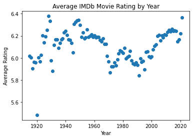

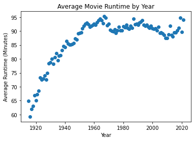

```python
trimmedMovieData = averageMovieData[averageMovieData["year"] >= 1915]

plt.scatter(trimmedMovieData["year"], trimmedMovieData["averageRating"])
plt.title("Average IMDb Movie Rating by Year")
plt.xlabel("Year")
plt.ylabel("Average Rating")
plt.show()

plt.scatter(trimmedMovieData["year"], trimmedMovieData["averageRuntime"])
plt.title("Average Movie Runtime by Year")
plt.xlabel("Year")
plt.ylabel("Average Runtime (Minutes)")
plt.show()
```

Now, we see that for every year between 1915 and 2021, with the odd exception of 1920, the average IMDb rating is contained entirely within the fairly small range of 5.8 to 6.4 out of 10 stars. There are no obvious linear or polynomial trends in rating, unfortunately, though we see that the period from 1970 to 2000 generally has lower ratings than the time ranges that come before and after. One plausible explanation for this is that IMDb users are split between casual demographics that like more modern, post-2000 films and others (potentially critics) that have a taste (or feeling of nostalgia) for older classics. After all, in the [updated 2007 version](https://www.afi.com/afis-100-years-100-movies-10th-anniversary-edition/) of the American Film Institute's list of 100 movies mentioned previously, only twelve were released in 1990 or later.

Conversely, there is most definitely a pattern that appears in the runtime versus year plot. Namely, from 1915 onwards, the runtime appears to increase steadily from about 60 minutes on average to between 90 and 95 by the year 1960. At that point, it remains roughly constant, perhaps even decreasing a bit to 85 minutes around the year 2010.

For the sake of curiosity, we can also choose to plot average rating against average runtime to see if there is any correlation between the two variables. However, we want to do this not by year, but by the specific title. This necessitates some cleaning of the data first.

We need to make sure that every entry in the data table has both a runtime and an average user rating, or else there is nothing left for us to put on the plot. Additionally, we need to make sure that this is all stored as numeric data rather than as string objects so that we may plot it nicely and perform further analysis on it if necessary.

```python
# Fixes the runtime column of the table
def fixRuntime(r):
    if r == "\\N":
        return np.nan
    return int(r)

# Fix all runtimes and then drop rows with missing data
newMovieData = movieData.copy()
newMovieData["runtimeMinutes"] = newMovieData["runtimeMinutes"].map(fixRuntime)
newMovieData = newMovieData.dropna()

newMovieData.head()
```

|  | tconst | titleType | primaryTitle | startYear | runtimeMinutes | averageRating |
| --- | --- | --- | --- | --- | --- | --- |
| 498 | tt0000502 | movie | Bohemios | 1905 | 100.0 | 4.5 |
| 570 | tt0000574 | movie | The Story of the Kelly Gang | 1906 | 70.0 | 6.1 |
| 587 | tt0000591 | movie | The Prodigal Son | 1907 | 90.0 | 6.0 |
| 672 | tt0000679 | movie | The Fairylogue and Radio-Plays | 1908 | 120.0 | 5.2 |
| 1172 | tt0001184 | movie | Don Juan de Serrallonga | 1910 | 58.0 | 3.4 |

The output above aligns with what we would expect. *Bohemios* is still the first appearance in the list, but *Robbery Under Arms* and *Hamlet* have been removed because they had no listed runtime. However, there is still a problem, visible below.

```python
newMovieData.sort_values("runtimeMinutes", ascending=False).head()
```

|  | tconst | titleType | primaryTitle | startYear | runtimeMinutes | averageRating |
| --- | --- | --- | --- | --- | --- | --- |
| 7123987 | tt8273150 | movie | Logistics | 2012 | 51420.0 | 6.4 |
| 4606958 | tt2659636 | movie | Modern Times Forever | 2011 | 14400.0 | 6.4 |
| 1450787 | tt10844900 | movie | Qw | 2019 | 10062.0 | 8.0 |
| 4459241 | tt2355497 | movie | Beijing 2003 | 2004 | 9000.0 | 7.7 |
| 272270 | tt0284020 | movie | The Cure for Insomnia | 1987 | 5220.0 | 5.1 |

The top few entries in the table have absurdly long runtimes! The first, *Logistics*, would take more than five weeks of continuous watching to finish completely. Besides ruining any useful visualization, this introduces another issue into the analysis: Internet "trolls."

As is evident from reading the [user reviews of *Logistics*](https://www.imdb.com/title/tt8273150/reviews?ref_=tt_urv), many ratings are being submitted as joke content rather than as a serious and sincere reflection of personal opinion. For example, one review is titled "Had to watch it twice to make sure I wasn't missing any details," and another includes the following excerpt:

> Starts off slow, the first 3 and a half days of runtime are kinda boring, but OMG by the 4th through 25th day things really pickup, and the final 10 days had me on the edge of my coma.

Thus, in order to reduce the effect of extreme outliers like these, we choose to slice away the top and bottom 0.05% of films by runtime. If there is indeed any relation between rating and runtime, it should still be apparent then, after removing the few films on either extreme.

```python
numMovies = len(newMovieData)
cutoff = .0005 # Proportion of data to cut from each end

# Set upper and lower bounds on the data that we will keep
lower = round(numMovies * cutoff)
upper = round(numMovies * (1 - cutoff))
cutoffMovieData = newMovieData.sort_values("runtimeMinutes", ascending=False)[lower : upper]

cutoffMovieData.head(300000)
```

|  | tconst | titleType | primaryTitle | startYear | runtimeMinutes | averageRating |
| --- | --- | --- | --- | --- | --- | --- |
| 3867318 | tt1720130 | movie | Karamay | 2010 | 356.0 | 8.4 |
| 7695508 | tt9485592 | movie | Girl Blood Sport | 2019 | 354.0 | 3.6 |
| 4276639 | tt2148482 | movie | The Ultimate Civil War Series: 150th Anniversa... | 2012 | 353.0 | 6.9 |
| 8240 | tt0008355 | movie | The Mystery of the Double Cross | 1917 | 350.0 | 6.4 |
| 4975509 | tt3526810 | movie | Adolf Hitler: The Greatest Story Never Told | 2013 | 350.0 | 7.5 |
| ... | ... | ... | ... | ... | ... | ... |
| 249344 | tt0260053 | movie | Gogi Ratiani | 1912 | 45.0 | 6.8 |
| 3992251 | tt1851881 | movie | Crew Film: TheVolume | 2010 | 45.0 | 5.8 |
| 249314 | tt0260022 | movie | Ferocious Female Kickboxing | 1981 | 45.0 | 3.1 |
| 195020 | tt0202841 | movie | Cruel Rhythm | 1991 | 45.0 | 8.1 |
| 7171556 | tt8374338 | movie | Deep Sea Killers | 2017 | 45.0 | 7.0 |

236088 rows × 6 columns

Now, the maximum runtime is (only) 356 minutes long, which, while it makes *Gone with the Wind* look paltry by comparison, is not unfathomable like before. Likewise, the minimum runtime is 45 minutes, which is perfectly reasonable. We can proceed to plotting the data.

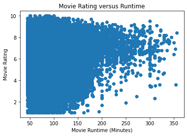

```python
plt.scatter(cutoffMovieData["runtimeMinutes"], cutoffMovieData["averageRating"])
plt.title("Movie Rating versus Runtime")
plt.xlabel("Movie Runtime (Minutes)")
plt.ylabel("Movie Rating")
plt.show()
```

Unfortunately, we now have the problem that the data is so dense that it is largely impossible to draw any conclusions from the above scatterplot. Let's try and aggregate the information into a violin plot by grouping together all points within twenty-minute runtime intervals.

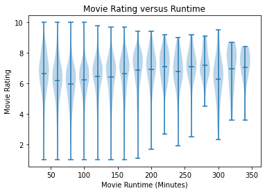

```python
width = 20 # Width of our runtime bucket, in minutes

ratingsPerRuntime = []

# Calculate the placement into buckets based on runtime
runtimeBuckets = (cutoffMovieData["runtimeMinutes"] // width) * width
uniqueBuckets = list(range(int(min(runtimeBuckets)), int(max(runtimeBuckets)) + 1, width))

# For each runtime bucket, get a list of IMDb ratings
for r in uniqueBuckets:
    runtimeRatings = cutoffMovieData[(cutoffMovieData["runtimeMinutes"] // width) * width == r]
    ratingsPerRuntime.append(list(runtimeRatings["averageRating"]))

plt.violinplot(ratingsPerRuntime, uniqueBuckets, widths=15, showmeans=True)
plt.title('Movie Rating versus Runtime')
plt.xlabel('Movie Runtime (Minutes)')
plt.ylabel('Movie Rating')
plt.show()
```

When organized like this, it becomes immediately clear that while the distribution of rating certainly changes significantly with runtime, the average remains roughly constant at between 6 and 7 out of 10 stars. Thus, it seems there is no sense in trying to fit a regression or determine a significant correlation between rating and runtime, in general.

# Further Evaluation

In the previous section, we explored to try and find if any interesting relationships occurred between the variables of interest in our data. In particular, we tried the following:

1. Quantity of movies versus year
2. Average IMDb rating versus year
3. Average runtime versus year
4. IMDb rating versus runtime

To summarize, we observed that the quantity of movies increased dramatically over time (1), especially past the year 2000. There was very clearly a nonlinear relationship to this increase, and there were in fact several features of the data that were directly attributable to current and past historical events.

The average rating versus year (2) and rating versus runtime (4) plots, on the other hand, clearly exhibited no useful trends upon visual inspection, and any tools or techniques like polynomial regressions that suggest otherwise would simply be misleading.

We are investigating the dependence of average film runtime on year, so our null hypothesis $H_0$ is the claim that runtime is independent of year. In terms of variables, if our linear regression yields the equation $\beta_0+\beta_1x$, then this is equivalent to saying $\beta_1=0$. We set our significance level at $\alpha=0.05$, since this is the industry standard for non-critical applications. (There is no noteworthy danger to individuals or to society that can come from a type I error here, so there is no particular need for us to designate a lower value of $\alpha$.)

For finding a linear regression to plot on top of our scatterplot, we use `numpy`'s built-in polynomial fit function, which simply requires input data, output data, and a degree for the polynomial. Then, to evaluate the fitness of this model, we use the `statsmodels` package with the ordinary least-squares (OLS) analysis to produce a summary of relevant statistical quantities.

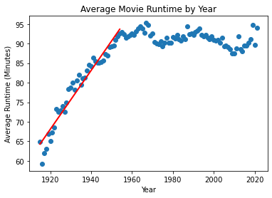

OLS Regression Results

| Dep. Variable: | Runtime | R-squared: | 0.943 |
| --- | --- | --- | --- |
| Model: | OLS | Adj. R-squared: | 0.941 |
| Method: | Least Squares | F-statistic: | 624.0 |
| Date: | Sun, 16 May 2021 | Prob (F-statistic): | 3.47e-25 |
| Time: | 10:11:39 | Log-Likelihood: | -87.281 |
| No. Observations: | 40 | AIC: | 178.6 |
| Df Residuals: | 38 | BIC: | 181.9 |
| Df Model: | 1 |  |  |
| Covariance Type: | nonrobust |  |  |

|  | coef | std err | t | P>\|t\| | [0.025 | 0.975] |
| --- | --- | --- | --- | --- | --- | --- |
| Intercept | 64.2971 | 0.683 | 94.133 | 0.000 | 62.914 | 65.680 |
| Year | 0.7530 | 0.030 | 24.981 | 0.000 | 0.692 | 0.814 |

| Omnibus: | 0.694 | Durbin-Watson: | 0.718 |
| --- | --- | --- | --- |
| Prob(Omnibus): | 0.707 | Jarque-Bera (JB): | 0.578 |
| Skew: | -0.281 | Prob(JB): | 0.749 |
| Kurtosis: | 2.823 | Cond. No. | 44.5 |

Notes:  
[1] Standard Errors assume that the covariance matrix of the errors is correctly specified.

```python
import statsmodels.formula.api as sm

x = np.array(trimmedMovieData["year"][:40])
y = np.array(trimmedMovieData["averageRuntime"][:40])
degree = 1 # We want a linear regression

# Make numpy linear regression
weights = np.polyfit(x, y, degree)
fit = np.poly1d(weights)

# Do scatterplot and draw regression
plt.scatter(trimmedMovieData["year"], trimmedMovieData["averageRuntime"])
plt.plot(x, fit(x), color="red", linewidth=2)
plt.title("Average Movie Runtime by Year")
plt.xlabel("Year")
plt.ylabel("Average Runtime (Minutes)")
plt.show()

# Alpha = 0.05 is implicit in the call to .fit(), according to
# https://www.statsmodels.org/stable/generated/statsmodels.regression.linear_model.RegressionResults.summary.html
df = pd.DataFrame(columns=['Year', 'Runtime'])
df['Year'] = (x - 1915)
df['Runtime'] = y

# Get regression fitness statistics
model = sm.ols(formula="Runtime ~ Year", data=df).fit()
model.summary()
```

From the output above, we see that the linear regression yields the equation $\text{Runtime}\approx64.3+0.753\text{(Year - 1915)}$, where runtime is measured in minutes. The graph of the curve on top of the scatterplot from before certainly appears to be a very good fit for the data from a cursory inspection. From the `statsmodels` summary, though, we can infer a few more detailed numerical properties of the model and its fitness. [This post](https://medium.com/swlh/interpreting-linear-regression-through-statsmodels-summary-4796d359035a) and [this post](https://www.accelebrate.com/blog/interpreting-results-from-linear-regression-is-the-data-appropriate) each provide good explanations for the different quantities in the above table and how to interpret them properly.

From the $R^2$ value, we see that the linear fit based on release year accounts for roughly 94.3% of the variability in the average film runtime from 1915 to 1955.

The P-value for the slope of the regression line is rounded to 0.000, which means it is far less than the significance level of 0.05 that was chosen previously. We can even see that the 95% confidence interval for the value of the slope was given by $[0.692, 0.814]$. Thus, the chance that film running time was independent of year in the span from 1915 to 1955 is vanishingly small.

Some of the values at the very end of the table help us to check whether the proper assumptions for a linear regression are met.

The Omnibus and Jarque-Bera tests both check the normalcy of the residuals, and the associated probabilities tell the probability that the residuals are in fact normally distributed. These values of 0.707 and 0.749 are quite high, indicating that this is a fairly good assumption.

To check if residual variances are constant (homoscedasticity), we can look at the Durbin-Watson value. Ideally, this would lie between 1 and 2. Unfortunately, in this instance, the regression produced a value of 0.718, which is suboptimal and may indicate that variances are not constant. In context, this could make sense, as the film industry matured and runtimes became more standardized over time.

The different values for runtime (and the resulting residuals) are certainly independent from one another by nature, since the runtime of one movie does not directly impact that of another. Finally, there definitely does appear to be a fundamentally linear relationship between runtime and year within this specific date range, which is likely due to gradual experimentation by filmmakers and adjusting of public expectations.

# Conclusion

At the beginning, we set out to learn how movies have changed over time. More specifically, we wanted to find answers to two of the most common questions on the subject:

- Have movies been getting better/worse?
- Have movies been getting longer?

In our preceding exploration and analysis, we have found satisfactory answers to each of these questions.

To address the first point, there was not sufficient evidence from IMDb user reviews to conclude that movie quality has changed significantly over the course of filmmaking's relatively brief history. In almost every year since the end of World War I, the average rating by year has fallen in the range of 5.8 to 6.4 stars out of a total of ten.

Though the IMDb ratings have not changed much, this is not definitive proof that movie quality has stagnated. For example, it could very well be the case that, as conjectured before, certain demographics tend to regard films from certain time periods more highly than others just by nature, or that older films' ratings are artificially inflated by nostalgia.

As for whether movies have been getting longer, we have more solid evidence from which we can draw conclusions. Namely, we found that while average movie runtime has remained about constant between 85 and 95 minutes from about 1955 to the present day, this has not always been the case. Instead, average movie runtime increased approximately linearly with time between the years 1915 and 1955, at a rate of about 0.75 additional minutes every year.

This change in runtime was likely due to maturation of the movie industry as filmmakers and directors attempted to find the right balance between the minimum time needed for good storytelling and the maximum time for which they could maintain the interest of a general audience. Coincidentally, this transition from increasing to roughly constant runtime also happens to align with the end of the golden age and the [transition from black-and-white to color](https://www.liveabout.com/how-movies-went-from-black-white-to-color-4153390) in Hollywood, another sign that the industry was developing.

In short, the next time you hear someone complain about how movies are so long nowadays, unless they're old enough to remember black-and-white films in theaters, they're probably looking back through rose-tinted glasses.